# Integrative Analysis using MFA

# Introduction

```r
load("./datasets/input.matrix.genes.Rda")
matGenes <- my.matrix; dim(matGenes)
```

```
## [1] 200 150
```

```r
load("./datasets/input.matrix.prots.Rda")
matProts <- my.matrix; dim(matProts)
```

```
## [1] 111 150
```

```r
load("./datasets/exclusive.matrix.genes.Rda")
AnotsOnlyGenes <- exclusive_expmat; dim(AnotsOnlyGenes)
```

```
## [1]   3 150
```

```r
load("./datasets/exclusive.matrix.prots.Rda")
AnotsOnlyProts <- exclusive_expmat; dim(AnotsOnlyProts)
```

```
## [1]  51 150
```

```r
load("./datasets/intersect.matrix.Rda")
AnotsProtsAndGenes <- intersect.matrix; dim(AnotsProtsAndGenes)
```

```
## [1]  10 150
```

# Applying MFA

While the application of MFA is that of an exploratory analysis, so that there is no unique approach the list provided by [Husson et Josse (2010)](https://www.r-project.org/conferences/useR-2010/tutorials/Husson+Josse.pdf) is a useful “checklist” to organize the analysis:

0. Define the structure of the data (groups of variables and/or individuals)
1. Define groups of active and supplementary variables
2. Scale or not the variables
3. Perform MFA
4. Choose the number of dimensions to interpret
5. Simultaneously interpret the individuals and variables graphs
6. Study the groups of variables
7. Study the partial representations
8. Use indicators to enrich the interpretation

## Data structure: defining groups

The expanded matrices contain either genes or proteins and a set of new variables derived from the selected annotations for each dataset.

```r
sum(colnames(matGenes)!=colnames(matProts))
```

```
## [1] 0
```

In order to apply MFA we need a unique matrix obtained by merging both datasets through its common dimension, which is set to be “rows”, transposing the original matrices.

Define the dataset(s)

```r
jointBasicData <- cbind(t(matGenes),
                        t(matProts))
jointBasicDataScaled <- cbind(scale(t(matGenes)),
                        scale(t(matProts)))

jointExpandedData <- cbind(t(matGenes),
                        t(matProts),
                        t(AnotsOnlyGenes) ,
                        t(AnotsOnlyProts),
                        t(AnotsProtsAndGenes))
jointExpandedDataScaled <- cbind(scale(t(matGenes)),
                        scale(t(matProts)),
                        scale(t(AnotsOnlyGenes)),
                        scale(t(AnotsOnlyProts)),
                        scale(t(AnotsProtsAndGenes)))
```

Groups are defined implicitly by the (number of) columns of the data matrix they are made of.

```r
numGenes <- ncol(t(matGenes))
numProts <- ncol(t(matProts))
numAnotsOnlyGenes <- ncol(t(AnotsOnlyGenes))
numAnotsOnlyProts <- ncol(t(AnotsOnlyProts))
numAnotsProtsAndGenes <- ncol(t(AnotsProtsAndGenes))
grupsBasic <- c(numGenes,numProts)
grupsExpanded <- c(numGenes,numProts,numAnotsOnlyGenes,numAnotsOnlyProts,  numAnotsProtsAndGenes)
```

Each group is given a name and it may be given a data type and a color.

```r
basicNames <- names(grupsBasic) <- c("genes", "prots")
expandedNames <- names(grupsExpanded) <- c("genes", "prots", "geneAnots", "protAnots", "commonAnots")
basicTypes <- c("c", "c")
expandedTypes <-c(rep("c", 5))
basicPalette <- c("yellow","red")
expandedPalette <- c("yellow","red","blue","orange","darkviolet")
```

## Defining active and suplementary variables

Variables describing biological knowledge are linear combinations of one or more omics variable types so it seems reasonable to start considering these as supplementary.

Supplementary groups are described by the index of the group in the vector that defines how many variables in each groups.

```r
supplGroups <- c(3,4,5)
```

## Scaling the variables

A quick check at the numerical part of the dataset can suggest if the data needs to be centered/scaled.

```r
boxplot(jointBasicData, col=basicPalette, cex.axis=0.6, las=2)
```

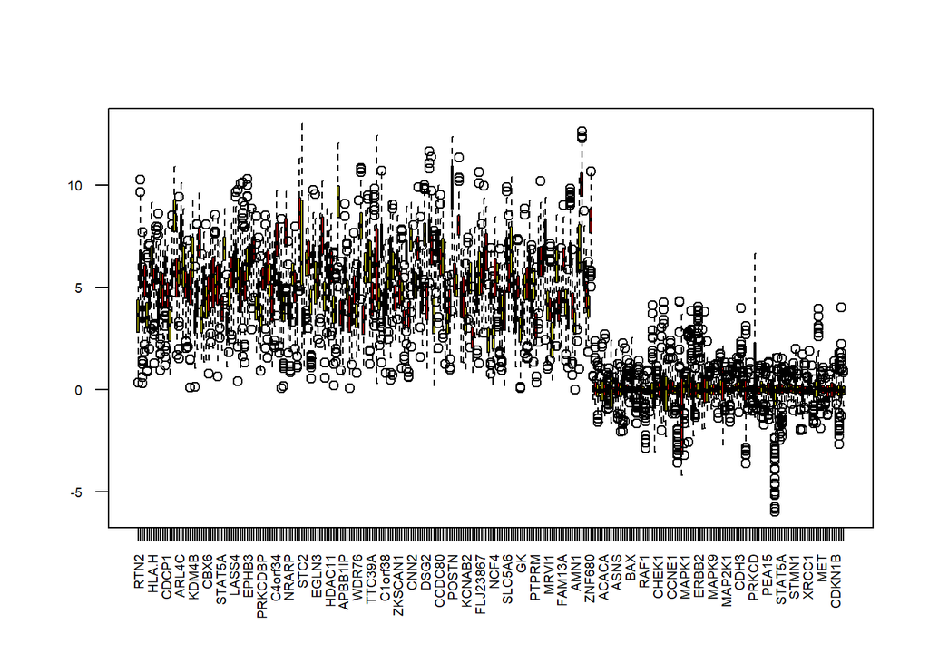

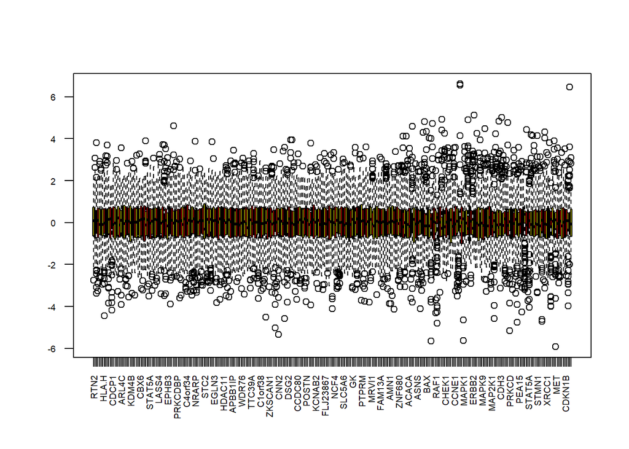

```r
boxplot(jointBasicDataScaled, col=basicPalette, cex.axis=0.6, las=2)
```

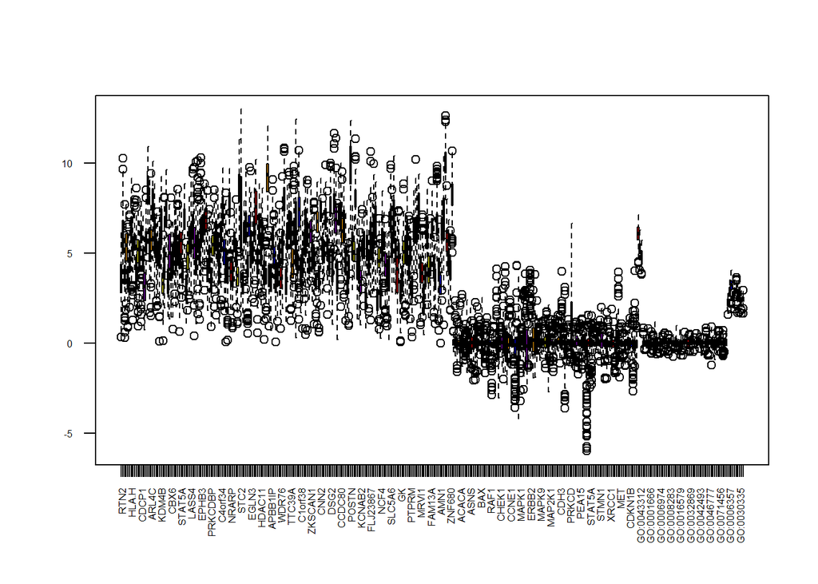

```r
boxplot(jointExpandedData, col=expandedPalette, cex.axis=0.5, las=2)
```

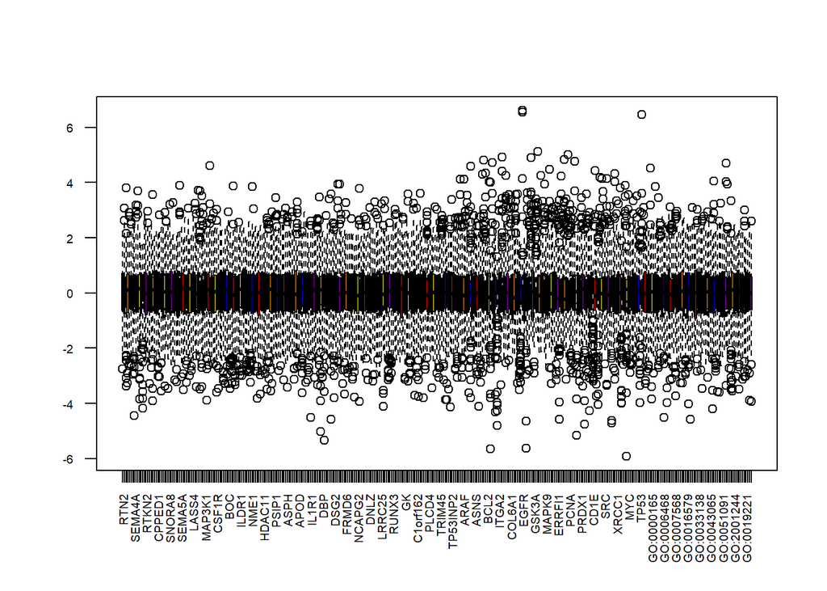

```r
boxplot(jointExpandedDataScaled, col=expandedPalette, cex.axis=0.6, las=2)
```

[figure not shown]

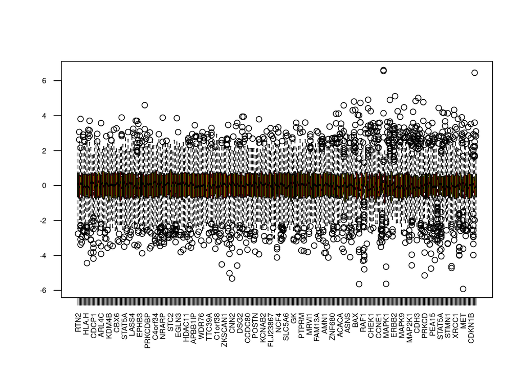

```r
boxplot(jointBasicDataScaled, col=basicPalette, cex.axis=0.6, las=2)
```

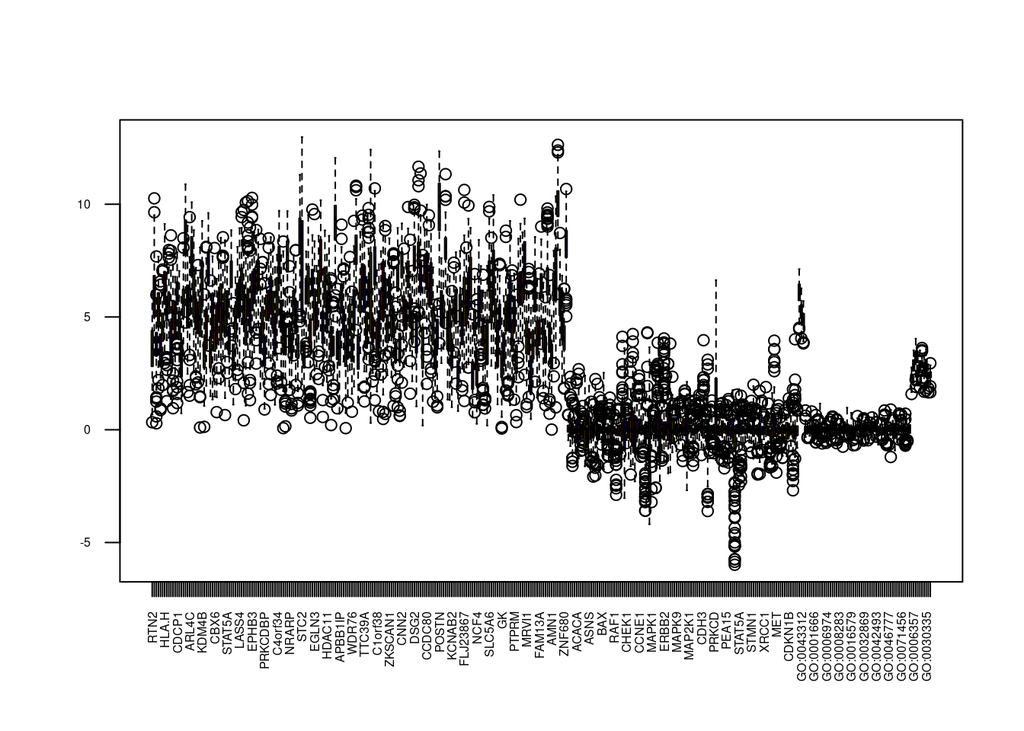

```r
boxplot(jointExpandedData, col=expandedPalette, cex.axis=0.5, las=2)
```

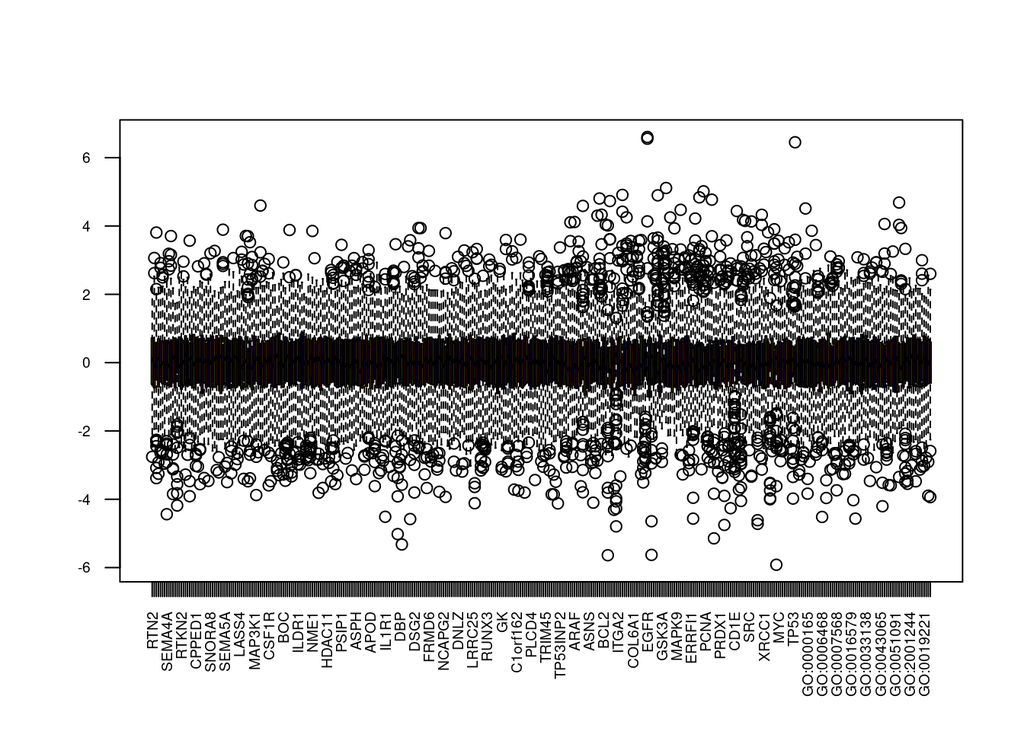

```r
boxplot(jointExpandedDataScaled, col=expandedPalette, cex.axis=0.6, las=2)
```

## Applying MFA

MFA is applied on the “expanded” matrix formed by expressions and annotations, that has been previously scaled.

```r
library(FactoMineR)
res.mfa<- MFA (base=jointExpandedDataScaled,
                      group=grupsExpanded,
                      name.group = names(grupsExpanded),
                      type=expandedTypes,
                      num.group.sup = supplGroups, graph=FALSE)
```

```r
dimdesc(res.mfa)
```

[output not shown]

## Representation of Groups

```r
plot(res.mfa,choix="group",palette=palette())
```

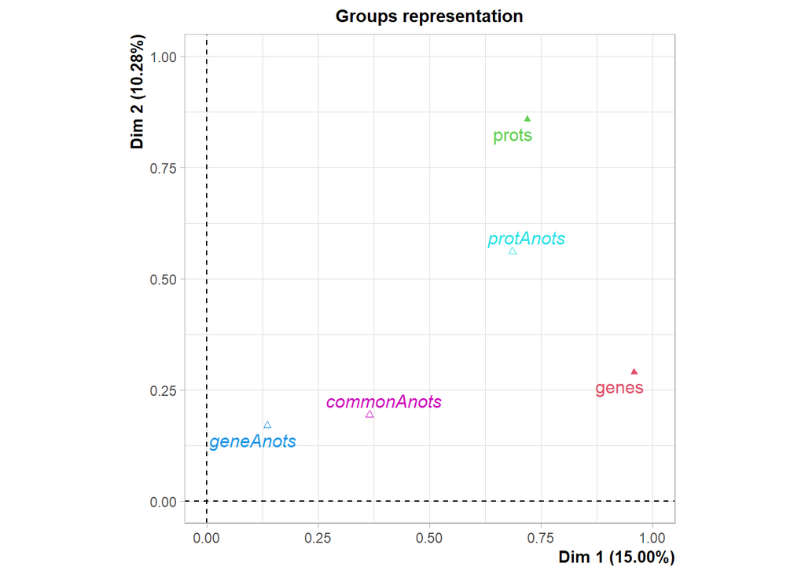

[figure not shown]

## Study of individuals and variables

```r
plot(res.mfa,choix="var",
     #invisible="quanti.sup",
     hab="group",
     lab.var=TRUE, lim.cos2.var = 0.6,
     palette=palette())
```

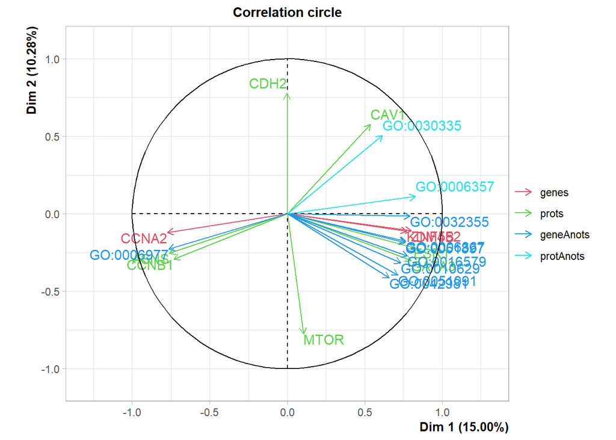

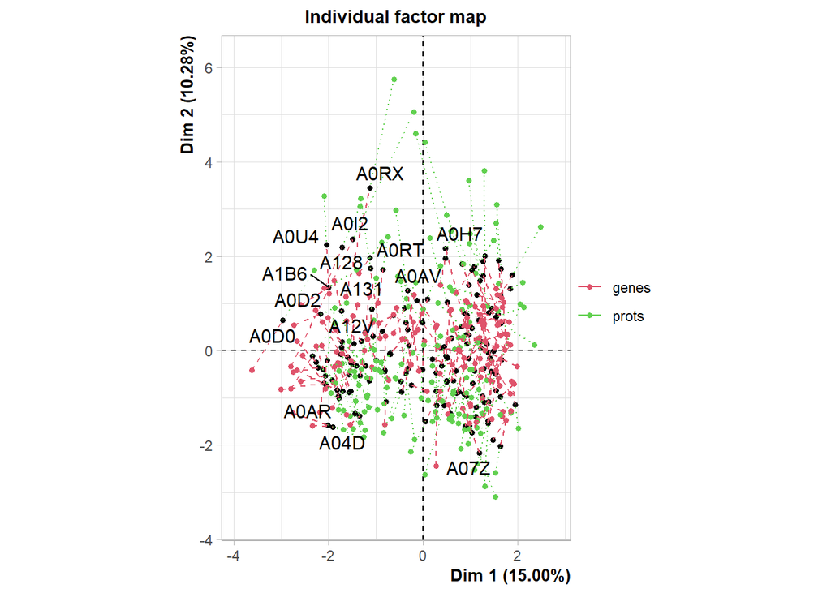

```r
plot(res.mfa,choix="ind",partial="all",habillage="group",palette=palette())
```

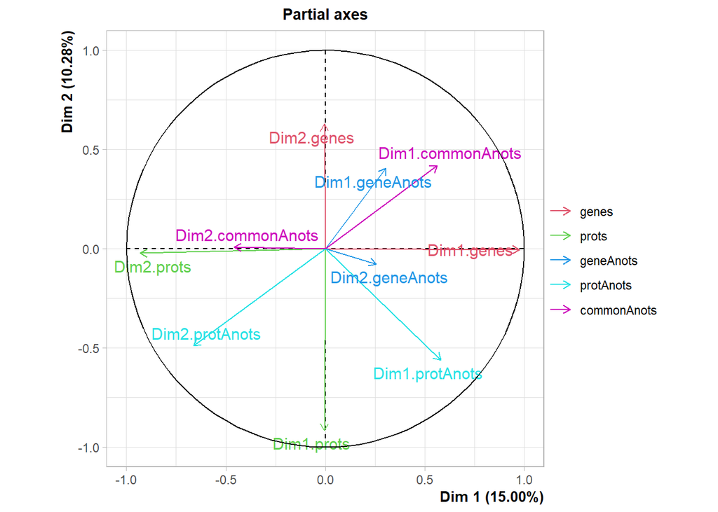

```r
plot(res.mfa,choix="axes",habillage="group",palette=palette())
```

[figure not shown]

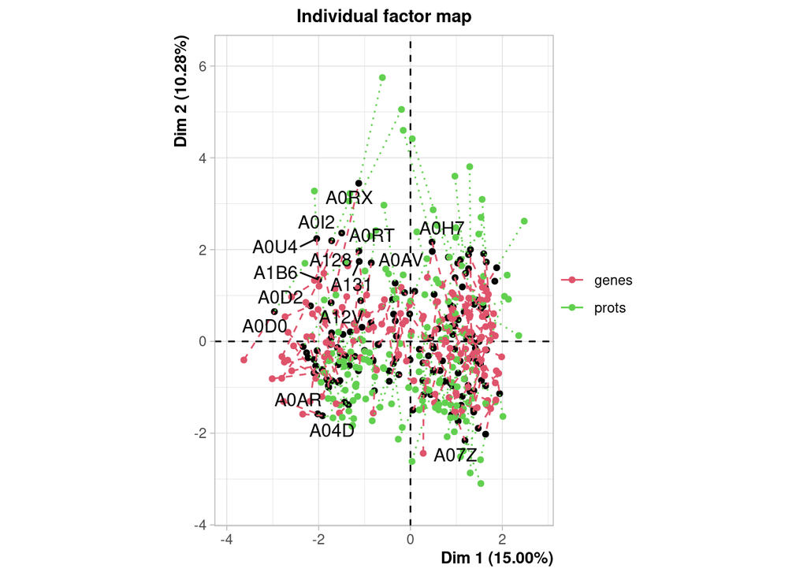

```r
plot(res.mfa,choix="ind",partial="all",habillage="group",palette=palette())
```

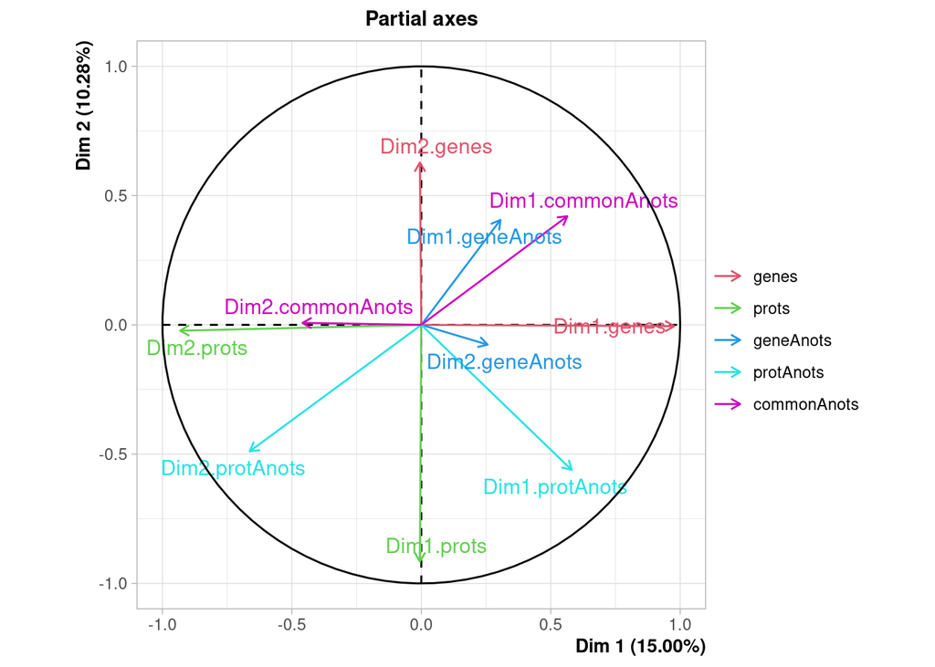

```r
plot(res.mfa,choix="axes",habillage="group",palette=palette())
```

## Automatic interpretation with `FactoInvestigate`

```r
library(FactoInvestigate)
Investigate(res.mfa)
```